# Machine Learning Project

Alison Hawthorne

21 April 2016

## Executive Summary:

This paper looks at weight-lifting data for 6 subjects performing bicep curls in 5 different manners (only one of which was correct). The aim of this project was to analyse the data to allow a prediction from the data for a similar dataset to determine which of the ways the exercise was performed.

The data was firstly split into two parts to allow training and testing via cross validation. Then the data was explored and pre-processed to identify the best variables with which to predict. I removed variables with near zero variance and variables that had very few observations against them. This cut-down the number of potential predictors from 159 to 53.

After some experimentation, I decided to use PCA and random forests to create my model. As there were so many variables, PCA provided a good method of determining which to use. Random forests was used for modelling to maximise accuracy in such a complex dataset. I checked for the potential drawback of overfitting by testing on my untouched test set. This still had excellent accuracy, hence this model was chosen.

## Cross Validation:

I read in the data and split the training set into two parts for my training and cross validation. I checked that the both datasets had a spread of data for all of the 6 subjects.

```r
        ##read in the data
        training <- read.csv("pml-training.csv",stringsAsFactors = FALSE)
        testing <- read.csv("pml-testing.csv",stringsAsFactors = FALSE)
        ##load the r libraries needed
        library(caret)
        library(dplyr)
        library(mice)
        set.seed(3212)
        ##partition the training set into training and test for cross validation
        intrain <- createDataPartition(y = training$classe, p = 0.7, list=FALSE)
        mytrain <- training[intrain,]
        mytest <- training[-intrain,]
```

## Pre-processing:

I firstly made the classe and user_name variables factor variables, as this seemed prudent.

```r
        ##make the classe variable and user name variables factor variables
        training$classe <- as.factor(training$classe)
        training$user_name <- as.factor(training$user_name)
```

There were 160 variables, which was somewhat intimidating! I decided to initially remove all variables will near zero variance, to try to reduce the number. I also removed the timestamp data as I found it spurious and could not work out how to interpret it usefully.

```r
        ##let's remove near zero covariates to try and get a reasonable number of predictors:
        nsv <- nearZeroVar(mytrain)
        mytrain2 <- mytrain[,-nsv]
        ##get rid of the timestamps as I can't see how to usefully use this
        mytrain2 <- mytrain2[,-(3:7)]
```

On investigation, I discovered that the remaining variables were either almost complete or almost empty. I thus decided to cut down yet further on my variables by removing the near empty ones. It seems to me that a variable that is only present for a small number of observations, is of little use in prediction.

[figure not shown]

```r
        ##a function to discover how empty each column is
        pMiss <- function(x){sum(is.na(x))/length(x)*100}
        emptycolumns <- apply(mytrain2,2,pMiss)

        plot(emptycolumns, main="Variable completeness", ylab="% of observations present for variable",
        xlab = "")
```

```r
        ##plotting shows that the variables are either complete or almost entirely empty.
        ##Therefore I am going to dump the columns that aren't complete
        ##a function to find columns that are complete
        colComp <- function(x){
                ##initiate empty vector to store the column positions that are full columns
                mycols <- vector("integer")
                for (i in seq_len(ncol(x))) {
                        ##if the column is complete, add its position to the vectos
                        if ((sum(is.na(x[,i]))) == 0) {
                                mycols <- c(mycols,i)
                        }

                }
                return(mycols)
        }

        mycompcols <- colComp(mytrain2)
        mytrain2 <- mytrain2[,mycompcols]
```

I examined some of my remaining predictors to see if I could ascertain any further information with which to decide on a model. I could see no obvious linear relationships and was not confident enough to cut the variables any further. The appendix contains a plot that is an example of one of my examinations.

I also pre-processed my test set by removing the near zero variables as identified in my training set and the same variables identified as near empty in the training set.

```r
        ##let's preprocess the test set so we can predict on it
        mytest2 <- mytest[,-nsv]
        mytest2 <- mytest2[,-(3:7)]
        mytest2 <- mytest2[,mycompcols]
```

## Modelling:

As discussed above, I decided to use PCA to pre-process my potential 53 predictors further and used random forests as the model as this maximised accuracy. When I cross-validated the model against my untouched test set, I discovered that the accuracy was still very high and thus this is my model of choice.

I have suppressed the code where I fit the model to remove the warning messages. However, for information it is as follows: modelFit <- train(classe ~., method=“rf”, preProcess=“pca”, data=mytrain2)

```r
        modelFit <- train(classe ~., method="rf", preProcess="pca", data=mytrain2)
```

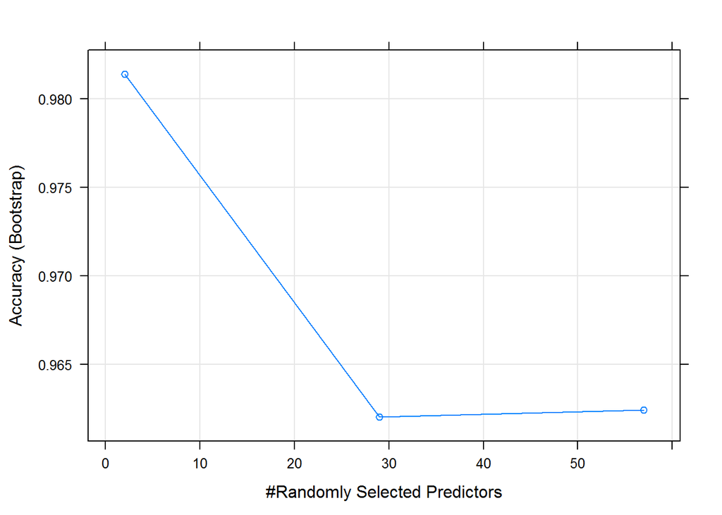

```
##
## Call:
##  randomForest(x = x, y = y, mtry = param$mtry)
##                Type of random forest: classification
##                      Number of trees: 500
## No. of variables tried at each split: 2
##
##         OOB estimate of  error rate: 1.16%
## Confusion matrix:
##      A    B    C    D    E  class.error
## A 3903    2    0    0    1 0.0007680492
## B   26 2608   23    0    1 0.0188111362
## C    0   27 2354   12    3 0.0175292154
## D    0    1   45 2204    2 0.0213143872
## E    0    0    3   13 2509 0.0063366337
```

## Outcome:

```r
        mypredictions <- predict(modelFit, newdata=mytest2)
        confusionMatrix(mypredictions, mytest2$classe)
```

```
## Confusion Matrix and Statistics
##
##           Reference
## Prediction    A    B    C    D    E
##          A 1671   11    0    0    0
##          B    3 1118   16    0    0
##          C    0    9 1003   22    0
##          D    0    1    7  941    5
##          E    0    0    0    1 1077
##
## Overall Statistics
##
##                Accuracy : 0.9873
##                  95% CI : (0.9841, 0.99)
##     No Information Rate : 0.2845
##     P-Value [Acc > NIR] : < 2.2e-16
##
##                   Kappa : 0.9839
##  Mcnemar's Test P-Value : NA
##
## Statistics by Class:
##
##                      Class: A Class: B Class: C Class: D Class: E
## Sensitivity            0.9982   0.9816   0.9776   0.9761   0.9954
## Specificity            0.9974   0.9960   0.9936   0.9974   0.9998
## Pos Pred Value         0.9935   0.9833   0.9700   0.9864   0.9991
## Neg Pred Value         0.9993   0.9956   0.9953   0.9953   0.9990
## Prevalence             0.2845   0.1935   0.1743   0.1638   0.1839
## Detection Rate         0.2839   0.1900   0.1704   0.1599   0.1830
## Detection Prevalence   0.2858   0.1932   0.1757   0.1621   0.1832
## Balanced Accuracy      0.9978   0.9888   0.9856   0.9867   0.9976
```

## References:

http://groupware.les.inf.puc-rio.br/har#weight_lifting_exercises Velloso, E.; Bulling, A.; Gellersen, H.; Ugulino, W.; Fuks, H. Qualitative Activity Recognition of Weight Lifting Exercises. Proceedings of 4th International Conference in Cooperation with SIGCHI (Augmented Human ’13) . Stuttgart, Germany: ACM SIGCHI, 2013.

## Appendix

A example of my data exploration:

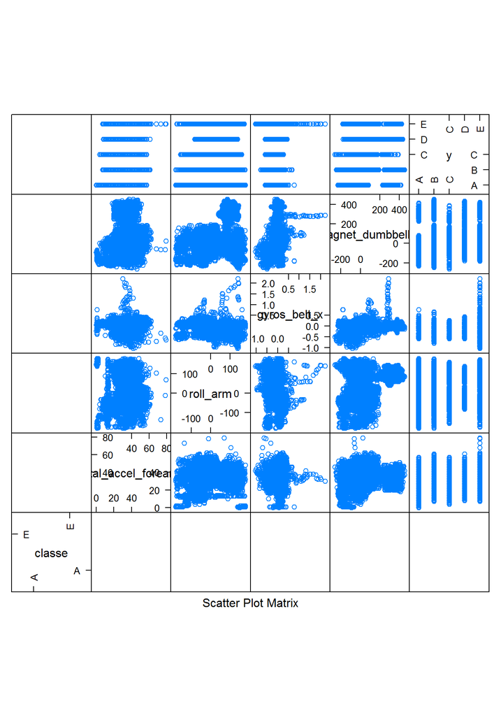

```r
        featurePlot(x=mytrain2[,c("classe","total_accel_forearm","roll_arm", "gyros_belt_x",
                                  "magnet_dumbbell_z")],y=mytrain2$classe,plot="pairs")
```